# Begroing elver forsurings indeks (AIP)

Kristina Øie Kvile, NIVA

21 februar 2025

Dette dokumentet går gjennom arbeidsflyten i R for å kjøre statistiske analyser og predikere NEQR-verdier for alle kommuner og ønskede år, for de indikatorene NIVA skal levere til Naturindeksen. De predikserte NEQR-verdiene blir lastet opp til NI-databasen ved hjelp av biblioteket NICalc i scriptet [NICalc_upload](https://github.com/NIVANorge/naturindeks/blob/main/analyser/NICalc_upload.r). Dette R markdown-dokumentet kan kjøres i løkke for flere variabler i scriptet [analyses_neqr](https://github.com/NIVANorge/naturindeks/blob/main/analyser/analyses_neqr.r).

# Databehandling

Først laster vi inn data for en indikatoren som skal analyseres, konvertert fra rådata til nEQR-verdier i scriptet convert2neqr.r. Vi laster også inn datasett med oversikt over alle kommuner, vannforekomster, økoregioner og vanntyper, for det relevante habitatet til den gitte indikatoren.

```
## [1] "Indikator: Begroing elver forsurings indeks (AIP)"
```

```
## [1] "Fil med nEQR-verdier (ForcingData): ../../01_Data/03_NEQR/NEQR_AIP.xlsx"
```

```
## [1] "Habitat: elver"
```

[output not shown]

```
## [1] "PredData: ../../01_Data/02_Vannforekomster/Naturindeks-elver.xlsx"
```

Observasjoner per år i ForcingData:

[output not shown]

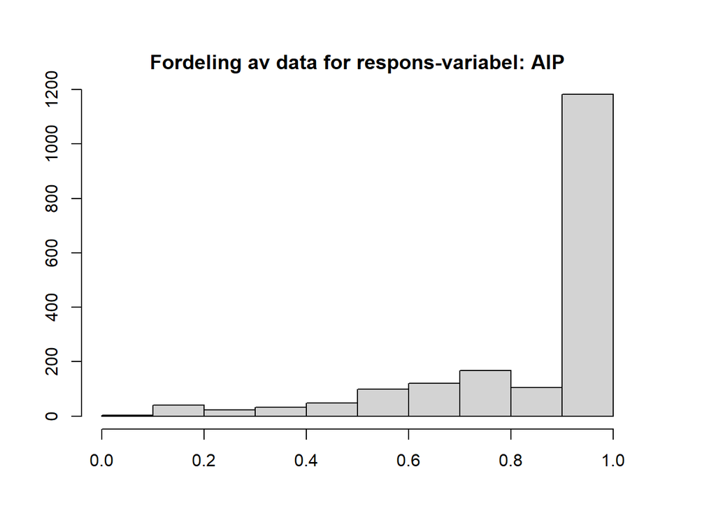

Vi klargjør datasettet for modelleringen ved å:  
1. Splitte “vanntype” i sine delkomponenter (“typologifaktorer”)  
2. Slå sammen de to nordlige økoregionene for ferskvann

Dette gjøres for både ForcingDataog og PredData.

For oversikt over typologifaktorer se [Klassifiseringsveileder 02:2018](https://www.vannportalen.no/veiledere/klassifiseringsveileder).

Observasjoner per økoregion i ForcingData:

| Okoregion | Ant. Vanntyper | Ant. obs |
| --- | --- | --- |
| E | 65 | 832 |
| M | 34 | 129 |
| N | 24 | 112 |
| S | 42 | 277 |
| W | 55 | 413 |

Observasjoner per økoregion i PredData:

| Okoregion | Ant. Vanntyper | Ant. obs |
| --- | --- | --- |
| E | 126 | 4373 |
| M | 125 | 4733 |
| N | 118 | 6350 |
| S | 118 | 3103 |
| W | 76 | 4436 |

Observasjoner per kode (nivå) i typologifaktorer for ForcingData:

| Kode | Vannkategori | Okoregion | Klimaregion | Storrelse | Kalk | Humus | Turbiditet |
| --- | --- | --- | --- | --- | --- | --- | --- |
| 1 | 0 | 0 | 0 | 668 | 491 | 1044 | 1763 |
| 2 | 0 | 0 | 0 | 626 | 889 | 640 | 0 |
| 3 | 0 | 0 | 0 | 257 | 316 | 0 | 0 |
| 4 | 0 | 0 | 0 | 153 | 67 | 79 | 0 |
| 5 | 0 | 0 | 0 | 59 | 0 | 0 | 0 |
| E | 0 | 832 | 0 | 0 | 0 | 0 | 0 |
| H | 0 | 0 | 114 | 0 | 0 | 0 | 0 |
| L | 0 | 0 | 823 | 0 | 0 | 0 | 0 |
| M | 0 | 129 | 826 | 0 | 0 | 0 | 0 |
| N | 0 | 112 | 0 | 0 | 0 | 0 | 0 |
| R | 1763 | 0 | 0 | 0 | 0 | 0 | 0 |
| S | 0 | 277 | 0 | 0 | 0 | 0 | 0 |
| W | 0 | 413 | 0 | 0 | 0 | 0 | 0 |

Observasjoner per kode (nivå) i typologifaktorer for PredData:

| Kode | Vannkategori | Okoregion | Klimaregion | Storrelse | Kalk | Humus | Turbiditet |
| --- | --- | --- | --- | --- | --- | --- | --- |
| 1 | 0 | 0 | 0 | 15449 | 6729 | 14011 | 22415 |
| 2 | 0 | 0 | 0 | 6548 | 11982 | 7169 | 258 |
| 3 | 0 | 0 | 0 | 738 | 3953 | 90 | 322 |
| 4 | 0 | 0 | 0 | 219 | 331 | 1322 | 0 |
| 5 | 0 | 0 | 0 | 41 | 0 | 0 | 0 |
| E | 0 | 4373 | 0 | 0 | 0 | 0 | 0 |
| H | 0 | 0 | 5575 | 0 | 0 | 0 | 0 |
| L | 0 | 0 | 5093 | 0 | 0 | 0 | 0 |
| M | 0 | 4733 | 12327 | 0 | 0 | 0 | 0 |
| N | 0 | 6350 | 0 | 0 | 0 | 0 | 0 |
| R | 22995 | 0 | 0 | 0 | 0 | 0 | 0 |
| S | 0 | 3103 | 0 | 0 | 0 | 0 | 0 |
| W | 0 | 4436 | 0 | 0 | 0 | 0 | 0 |
| NA | 0 | 0 | 0 | 0 | 0 | 403 | 0 |

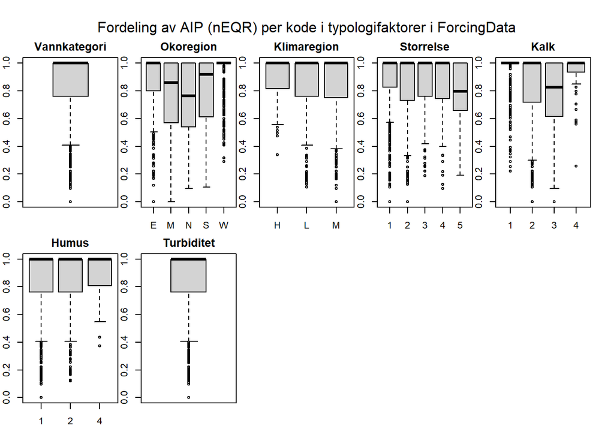

# Modell

Vi bruker en modell (GAM eller BRT) for å forklare variasjonen i NEQR ut i fra typologifaktorene som inngår i vanntype (kategoriske variabler) og år (kontinuerlig variabel). Dette muliggjør å predikere nEQR-verdier for kommuner og år med manglende data, basert på sammenhengen mellom observerte nEQR-verdier (responsvariabel) og typologifaktorer/år (forklaringsvariabler). Vi inkluderer kun typologifaktorer representert med minst to ulike koder i datasettet (ForcingData) i modellen. For kyst-habitat er salinitet, bølgeeksponering, miksing, oppholdstid og gjennomstrømming definert av kysttype (+ økoregion for salinitet), og vi bruker derfor kun typologifaktorene kysttype, økoregion og tidevann som forklaringsvariabler i modellen.

For å kunne inkludere typologifaktorene som faktorer i modellen må vi først:  
1. Fjerne eventuelle observasjoner med manglende verdier for typologifaktorene som skal inngå i modellen, både i ForcingData og PredData  
2. Fjerne eventuelle vannforekomster med typologifaktor-koder som ikke finnes i ForcingData fra PredData (her kan vi ikke predikere fra modellen)

Vi replikerer så PredData for alle år vi skal predikere for. I utgangspunktet skal vi levere oppdaterte prediksjoner for årene 1990, 2000, 2010, 2011, 2012, 2013, 2014, 2019 og 2024. Men for hver økoregion (og kysttype for kyst-indikatorer) predikerer vi kun for år fra og med første år vi har data for. For eksempel, om vi kun har data fra og med 2010 fra Skagerrak vil vi ikke predikere verdier for kommuner i Skagerrak før 2010.

```
## [1] "Antall ulike koder per typologifaktor:"
```

```
##   Vannkategori Okoregion Klimaregion Storrelse Kalk Humus Turbiditet
## 1            1         5           3         5    4     3          1
```

```
## Typologifaktorer som beholdes i modellen:
##  Okoregion Klimaregion Storrelse Kalk Humus
```

```
## Antall observasjoner i opprinnelig datasett (ForcingData) og etter fjerning av manglende data for typologifaktorer:
##  1763
##  1763
```

```
## Antall vannforekomster i PredData før og etter fjerning av vannforekomster med manglende data for typologifaktorer eller typologifaktor-koder som ikke finnes i ForcingData:
##  22995
##  22502
```

```
## Vi kan totalt sett predikere for følgende år:
##  2011 2012 2013 2014 2019 2024
```

[output not shown]

Vi bruker enten GAM (generalized additive model) eller BRT (boosted regression trees, se [A working guide to boosted regression trees](https://besjournals.onlinelibrary.wiley.com/doi/full/10.1111/j.1365-2656.2008.01390.x)) for å forklare variasjonen i nEQR som funksjon av typologifaktorene og år. I begge tilfeller inkluderer vi år som kontinuerlig variabel (smooth-funksjon i GAM), siden vi antar at det er (potensielt ikke-linjære) trender over tid (ikke tilfeldig år-til-år variasjon). Dette tillater oss å predikere for år vi eventuelt ikke har data for.

For GAM inkluderer vi interaksjoner mellom år og de kategoriske variablene, hvor den linjære effekten av de kategoriske variablene (stigningstallet) variererer som en “smooth funksjon” av år (definert med “by”-argument i GAM).

Vi beregner så predikert NEQR per år og vannforekomst ut i fra modellen og informasjon om vanntype per vannforekomst, og kalkulerer deretter gjennomsnitt predikert NEQR per kommune og år. Som nevnt over predikerer vi kun NEQR for kombinasjonen av vannforekomst og år med typologifaktor-koder som inngår i modellen (det finnes data for i ForcingData) og hvor vi har data fra samme økoregion (for ferskvann) eller økoregion OG kysttype (kyst) for samme år eller foregående år.

Siden BRT er en kombinasjon av statistisk regresjon og maskinlæring er ikke prediksjonene fra BRT assosiert med standardavvik slik som f.eks. en GAM. Vi gjør derfor en bootstrap-prosedyre hvor vi kjører BRTen 100 ganger med 90 % av datasettet og beregner prediksjoner fra denne kjøringer, før vi beregner gjennomsnitt og standardavvik fra disse 100 kjøringene. Dette er strengt tatt unødvendig siden BRT-prosedyren allerede er en iterativ prosess hvor et visst antall (i vårt tilfelle 70%) av datasettet blir brukt i hver iterasjon, og man beregner den beste modellen, og BRT har vist seg å ha bedre prediksjonsevne enn f.eks. GAM. Men boostrap-metoden tillater oss å beregne et standardavvik som vi kan bruke inn i beregningen av lognormalfordeling som trengs for å laste opp data til NI-basen.

```
## Type modell:
##  BRT
```

```
## [1] "Beste kombinasjon av parametere for BRT:"
##    learningRate treeComplexity bagFraction nTrees
## 18         0.01              4         0.7   2450
```

I noen tilfeller, spesielt med GAM, får vi prediksjoner over 1, som vi setter til 1.

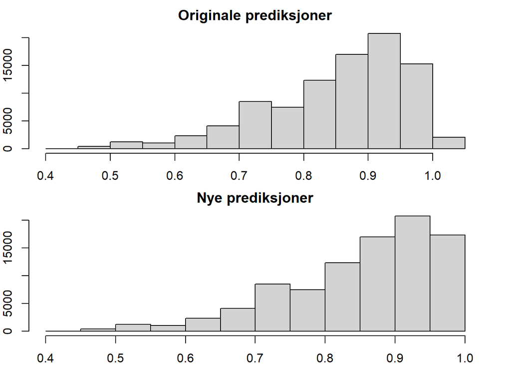

# Sammenligning mellom observasjonsdata og prediksjoner

Kartet under viser gjennomsnittilig NEQR per kommune, basert på innsamlede data per år i det tilgjengelige datagrunnlaget.

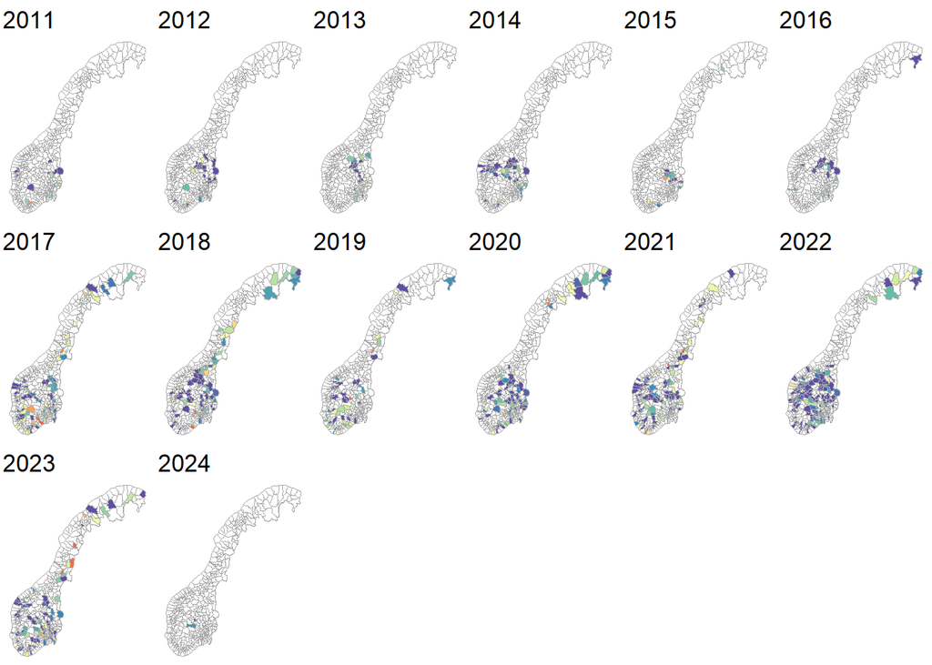

Gjennomsnitt NEQR-verdi per år og kommune.

Kartet under viser gjennomsnittilig predikert NEQR per kommune, basert på den statistiske modellen, for de årene som Naturindeksen skal leveres. Som beskrevet over beregnes prediksjonene kun for en gitt økoregion om vi har data fra den økoregionen (og kysttypen for marine indikatoren) for samme år eller foregående år.

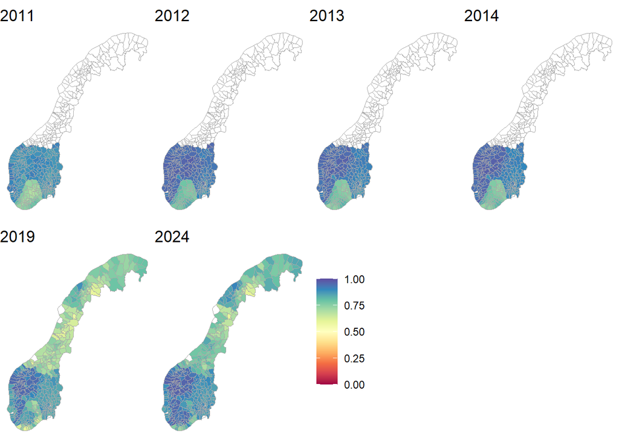

Predikert NEQR-verdi per år og kommune

Plottet under viser predikert NEQR per kommune sammenlignet med datagrunnlaget (gjennomsnittlig målt NEQR per kommune), for de kommunene hvor vi har data for samme år som prediksjonene gjøres. Korrelasjonskoeffisient og p-verdi for korrelasjonen er vist med rød skrift i plottet, og den linjære sammenhengen er vist som svart linje.

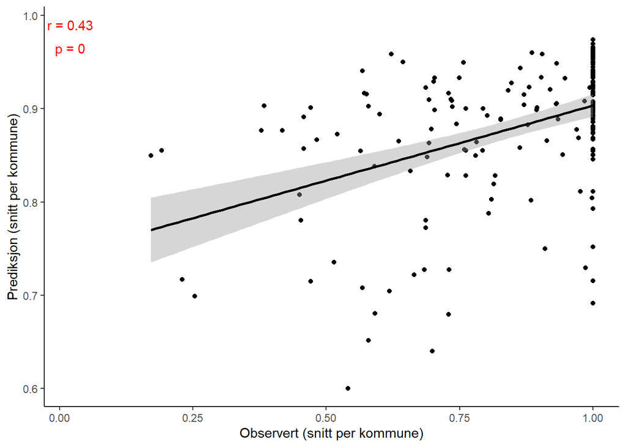

Korrelasjon mellom data og prediksjoner på kommunenivå.

# Gjennomsnittlige verdier per økoregion

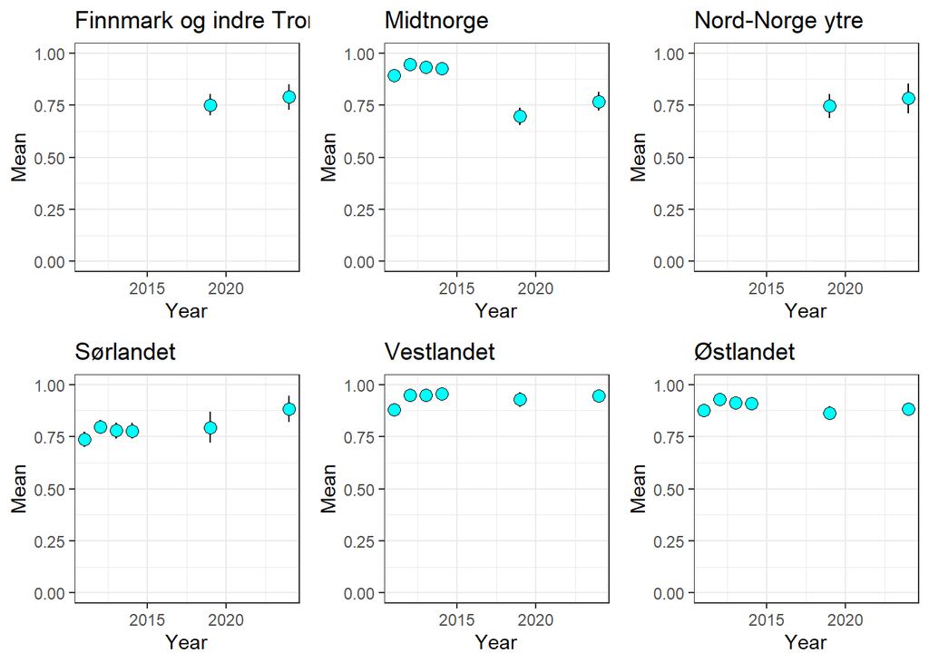

Gjennomsnitts-prediksjoner per år og økoregion (for ferskvann dekker kategorien Nord-Norge ytre hele Nord-Norge)

# Opplasting til NI-databasen

Predikerte NEQR-verdier blir lasta opp til NI-databasen på nett ved å bruke NIcalc-biblioteket i R i scriptet NICalc_upload.r. Laster først ned den eksisterende databasen for den gitte indikatoren, og oppdaterer så verdi (=prediksjon) og ‘distrObjects’ (beregnes av funksjoner i NIcalc). Verdier for kommuner og år vi ikke har prediksjoner for, men som finnes i databasen allerede, blir satt til NA.